# Week 1: Syntax Guide

## Example Code

The following code demonstrates all of the concepts covered in this week's syntax guide. Have a quick read and see if you can work out what the program does.

```
/// Program: HouseDrawing
///
/// This program opens a window and draws a picture of a house.

using System;
using SplashKitSDK;

namespace MyProgram
{

  public class Program
  {
    public static void Main()
    {
      Window houseWindow = new Window("House Drawing", 800, 600);

      Console.WriteLine("The house window is at ", houseWindow.X, ":", houseWindow.Y);

      houseWindow.Clear(Color.White);
      houseWindow.FillRectangle(Color.Grey, 300, 300, 200, 200);
      houseWindow.FillTriangle(Color.Red, 250, 300, 400, 150, 550, 300);
      houseWindow.FillEllipse(Color.BrightGreen, 0, 400, 800, 400);
      houseWindow.Refresh(60);

      SoundEffect tada = new SoundEffect("tada", "tada.wav");
      tada.Play();

      Console.WriteLine("Is tada playing? ", tada.IsPlaying);

      Utilities.Delay(5000);

      Console.WriteLine("Is tada still playing? ", tada.IsPlaying);

      houseWindow.Close();
    }
  }
}
```

When this runs it generates the following screenshot.

[figure not shown]

Screenshot of running program

## Code File

In C# your program's code is organised in one or more code files. Each of these files will have the following syntax:

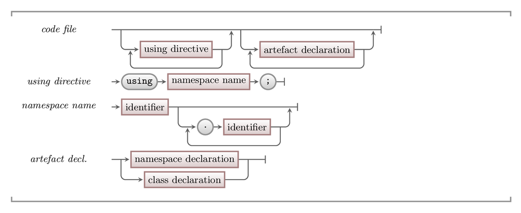

This diagram shows the syntax for a code file in C#.

- The code file includes **using directives** to give it easy access to library code that is written in a different [*namespace*.](https://en.wikibooks.org/wiki/C_Sharp_Programming/Namespaces)
- You can create one or more namespaces and/or classes within the file.

The following code is an example of what you could include in a code file. It includes two *using directives*: one to use the `System` namespace, the other to use the `SplashKitSDK` namespace. The body of the file then declares a namespace called `MyProgram`, which would then contain class declarations.

```
using System;
using SplashKitSDK;

namespace MyProgram
{
  // declare classes here...
}

class WebServer
{
  // declare methods here...
}
```

## Comments

You can add *comments* to your code that are ignored by the compiler. These comments document your programs, helping the reader to understand what parts of the code are doing. In C# there are two kinds of comments: single line comments, and block comments. Single line comments start with `//` and end a the end of the line. Block comments start with `/*` and end with `*/`.

The following code demonstrates the use of both comment styles.

```
/*
 * This is a block comment...
 * You dont need a * at the start of each line...
 * but it looks neat!
 */

class ThisIsCode
{
  // This is a comment
  public static void Main()
  {
    // so is this...
  }
}
```

## Artefact: Namespace Declaration

A **namespace** is a grouping structure in C#, used to organise classes and other artefacts into *namespace* groups. It is known as a *namespace* as each class *name* (its identifier) must be unique within its namespace. This gives each class a unique name that is a combination of the class's namespace and its name, for example the *SplashKit* class is in the *SplashKitSDK* namespace so its fully qualified name is `SplashKitSDK.SplashKit`.

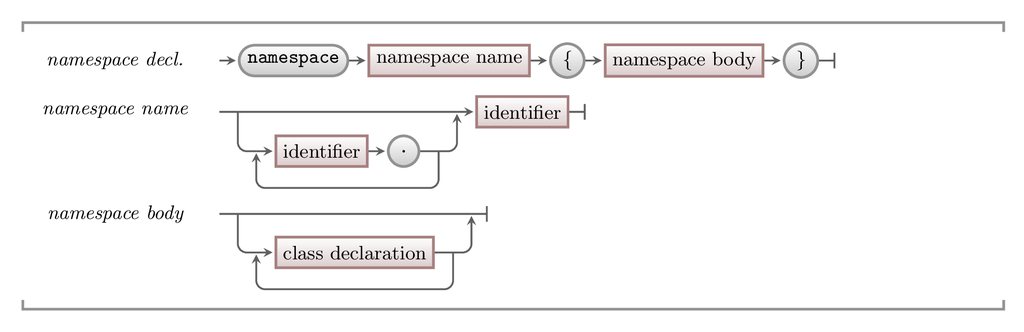

This diagram shows the syntax to create a namespace in C#.

- Namespace names should be in **PascalCase**.
- Namespaces can be nested in a hierarchy. For example, there is a namespace called `System` in the standard C# library, it contains a `Collections` namespace which in turn contains a `Generic` namespace which would have the full name of `System.Collections.Generic`.

## Artefact: Class Declaration

In C# your code is organised across a number of classes. These classes are used to describe the different kinds of objects you want to create within your program, but can also provide their own functionality beyond object creation.

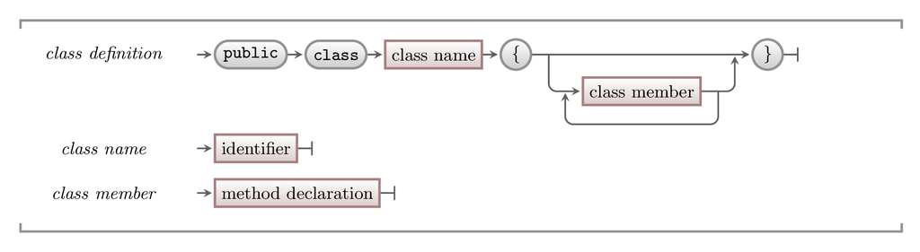

This diagram shows the syntax to create a class in C#.

- Class names should be in **PascalCase**.
- Each class can contain a number of *class members*.
- A class is an artefact, so you need to be able to picture it as existing within your program. Typically with a class you would picture the kinds of objects it can create, and imagine these objects as *actors* that are each playing the role defined by the class.
- The scope modifier controls who has access to the class. **Private** classes are hidden within the namespace, **public** classes are available for users outside the namespace.

The following code demonstrates the declaration of a namespace that contains one class declaration that creates the `Program` class.

```
using System;
using SplashKitSDK;

namespace MyProgram
{
  public class Program
  {
    // declare the Program class's methods here...
  }
}
```

## Artefact: Method Declaration

Methods provide the *brains* for your objects and classes, enabling them to **do things**. Each method describes a list of actions for the computer performs when that method is called.

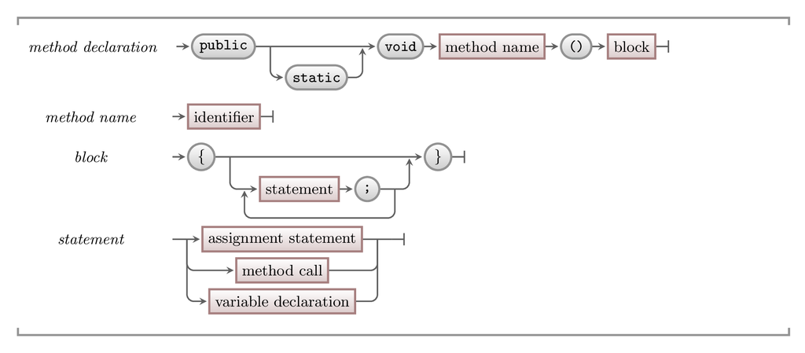

This diagram shows the syntax to create a method in C#.

- Method names should be in **PascalCase**.
- Methods **must** be declared within a class.
- The scope modifier controls who can call the method: **public** means any object/class can call the method, **private** means it can only be called from within the current class.
- By default methods are associated with objects created from the class.
- To assign the method to the class you add the `static` modifier in the method declaration. This puts the method on the class at runtime.
- The method contains a **sequence** of instructions (statements) that are run when the method is called.
- A method is an artefact, so you need to be able to picture it as existing within your classes. Each method becomes something that your object (or class for static methods) **can do**.
- To be a valid **program**, one of your classes must have a *static method* named **Main**. The `Main` method is the where the program starts.

The following code demonstrates the declaration of two classes: `Program` and `SecurityCard`. `Program` declares a single static method named **Main**, this is a special method name as it indicates the first method that is called when the code is run. The `SecurityCard` class declares two method, as these methods do not have the static keyword they are associated with `SecurityCard` objects. These are the standard kind of method, which are sometimes called **instance methods** as they exist within *instances* (objects) of the `SecurityCard` class.

```
using System;
using SplashKitSDK;

namespace MyProgram
{
  public class Program
  {
    // Main is a static method, so it exists on the Program class
    // at runtime.
    public static void Main()
    {
      // Write the sequence of statements to run here...
      // These are the instructions for Main when it is run
    }
  }

  public class SecurityCard
  {
    // Validate is a standard method, so it exists within each
    // SecurityCard object at runtime.
    public void Validate()
    {
      // Instructions for Validate go here...
    }

    // Another method on the SecurityCard objects...
    private void CheckDetails()
    {
      // Instructions for CheckDetails go here
    }
  }
}
```

## Terminology: Statement

In programming terminology a **statement** is an *instruction* for the computer to perform an action. Each method has a **sequence** of statements that define the actions that the computer performs when the method is called. Each programming language has only a few different kinds of statement. To start with we will make use of two different statements: the **method call** and **assignment statement**.

- Statements are actions that the computer can *execute*.
- There are only a few different kinds of statements.
- Each statement gets the computer to perform certain actions.

## Terminology: Expression

- When run, each expression is evaluated and becomes value
- Each expression has a certain **type** which describes the kind of value generated.
- Expressions can be coded as values directly, these are known as **literals**.

## Expression: Object Creation

The ability to create objects is central to object oriented programming. C# provides a **new** keyword that is used together with a class name in order to create a new *instance* (object) from that class.

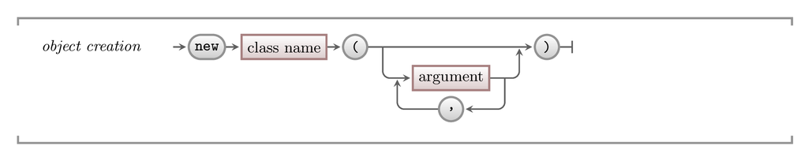

This diagram shows the syntax to create a new object in C#.

```
using System;
using SplashKitSDK;

public class Program
{
  public static void Main()
  {
    new Window("Knights", 600, 100);
    new Bitmap("google", "http://www.google.com.au/images/branding/googlelogo/2x/googlelogo_color_272x92dp.png", 80);

    SplashKit.Delay(5000);
  }
}
```

## Artefact: Variable Declaration

For the computer to "remember" anything, you need somewhere to store the data in memory. Variables allow you to store values in memory for later use. When you create a variable you indicate what kind of value you want to store, and the computer will allocate you enough space to store that kind of value.

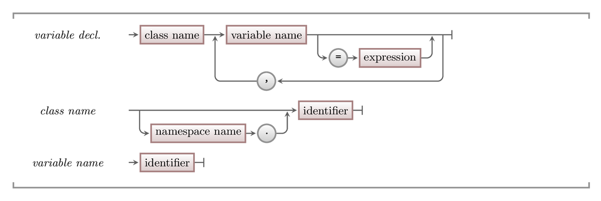

This diagram shows the syntax to create a local variable in C#.

## Statement: Assignment Statement

We will focus more on the Assignment statement next week. This statement will allow you to *remember* the objects you have created. The assignment statment stores the object's reference in the indicated variable. In this way your code can remember the objects you created so that you can use them later in your code.

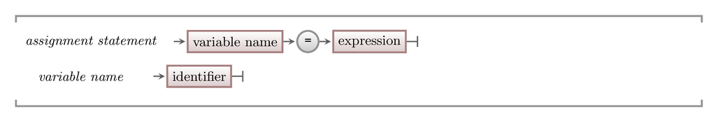

## Action: Method Call

A method call is an action you can get the computer to perform within a method (a statement). Method calls enable you to get an object (or class) to do something that has been coded in one of its methods.

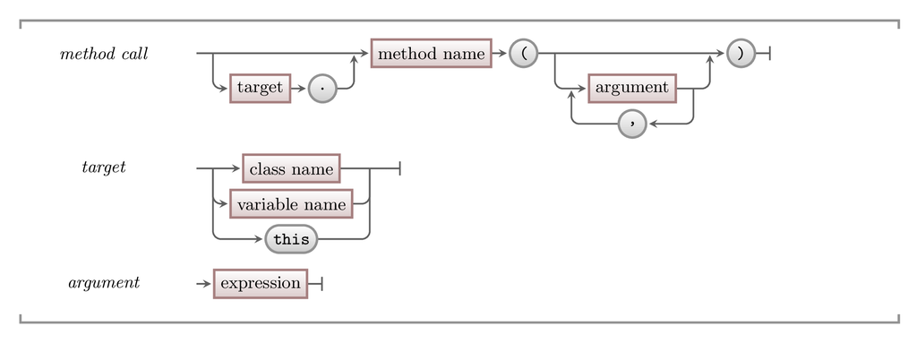

This diagram shows the syntax to get the computer to perform a method call in C#.

- The target is the object or class that the method is being called on. You can imagine this as a message being sent to the target asking them to *do something* (the something is whatever is coded in the method that is being called).
- You can use *arguments* to pass values to the method. These values can be calculated as each argument is an expression.
- A method call is an action, so you need to know how it works. The computer will perform the following actions (in order) when a method call is run:
1. Each argument's expression is evaluated so that each argument becomes a single value.
2. Control of the computer passes to the *method* on the *target*, with the argument values being passed in for the called method to use.
3. The instructions in the called method are now executed (it has control of the computer).
4. When the called method finishes its instructions, it ends and control returns.
5. This ends the method call, so control passes to the next statement within the current method.

1. The first method call runs the `WriteLine` method on the `Console` class. This has one argument, the text (string) `"Hello World!"`.
2. The next line is an assignment statement, it also includes a call to a **constructor** on the `Window` class. See the assignment statement for more details.
3. Next is a call to the `MoveTo` method on the object referred to by the `w` variable. This is being passed two arguments: the first with the value 100, and the second with the 20 (the result of calculating the expression 5 * 2 + 10).
4. `w.Clear(Color.White)` is a call to the `Clear` method on the Window object referred to be the `w` variable. This is passed a color value that is accessed from the `Color` class.
5. The remaining method calls include classes to `DrawText`, `Refresh`, and `Delay`.

```
using System;
using SplashKitSDK;

public class Program
{
  public static void Main()
  {
    Console.WriteLine("Hello World!");

    Window w = new Window("Knights", 600, 100);
    w.MoveTo(100, 5 * 2 + 10);
    w.Clear(Color.White);
    w.DrawText("We are the Knights who say 'Ni'!", Color.Black, 10, 50);
    w.Refresh();

    SplashKit.Delay(5000);
  }
}
```

## Terminology: Identifier

Identifier is the technical term for the names we give the artefacts within our code. Each identifier must start with a letter or an underscore, and can only contain letters, numbers, and underscores.

Errors that relate to unknown identifiers usually mean you have misspelt the name of an artefact, so the compiler cannot find what you are referring to.

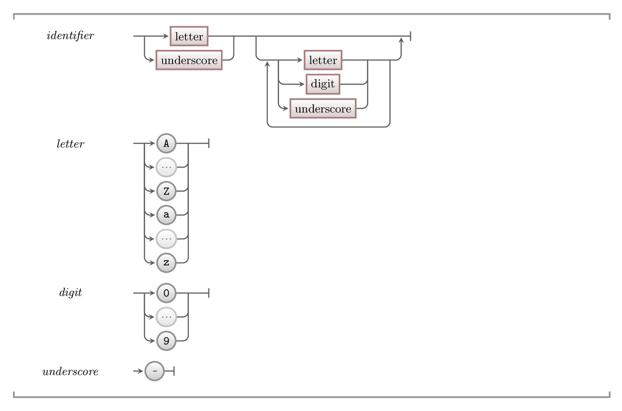

This diagram shows the syntax for an identifier in C#.

## Terminology: Argument

An **Argument** is a value passed to a method within a method call. Each argument is an expression whose value is calculated and passed to the method when it is called.

You use arguments to provide values for the method to use when it runs. For example, when you call `FillRectangle` you pass in the color of the rectangle and its coordinates. These values are then used by the method to determine the rectangle that is drawn to the screen.

Not to be confused with this kind of [argument](https://www.youtube.com/watch?v=0rTEzYbMiNM).

Namespaces in the online C# Programming text.